# SI 618 Homework 6: Clustering

## The total score for this assignment will be 100 points, consisting of:

- 10 pt: Overall quality of spelling, grammar, puctuation, etc. of written sentences.
- 10 pt: Code is written in [PEP 8](https://www.python.org/dev/peps/pep-0008/) style.
- 80 pt: Homework questions.

## Top-level Goal

Your overall goal in this assignment is to cluster airplane incidents according to the text contained in the summaries of the incidents. This will provide an opportunity for you to apply the methods we talked about in the lecture.

You should pick a decade (i.e. any contiguous 10-year span) of air crashes data, focus on the column called "summary" and try to cluster the air crashes based on these summaries using both hierarchical and k-means clustering.

Hint:

- Be careful with the choice of decade, some decades do not have sufficient data to play with.
- pandas.to_datetime is a useful function for transforming string-based dates to datetime objects in a dataframe.
- It's necessary to clean the data before you formally begin to answer the questions.

```python
from matplotlib import pyplot as plt
from scipy.cluster.hierarchy import dendrogram
from sklearn.datasets import load_iris
from sklearn.cluster import AgglomerativeClustering
import scipy.cluster.hierarchy as shc
%matplotlib inline
import pandas as pd
import seaborn as sns
import numpy as np
from collections import Counter
import nltk
from nltk.stem.wordnet import WordNetLemmatizer
import itertools
from sklearn.cluster import KMeans
from sklearn.decomposition import PCA
from sklearn.metrics import silhouette_score
from sklearn import metrics
from wordcloud import WordCloud
```

# Q1 (5 points) Download and describe the data

You can download the air crash dataset through this [page](https://opendata.socrata.com/Government/Airplane-Crashes-and-Fatalities-Since-1908/q2te-8cvq). Download the .csv file (Airplane_Crashes_and_Fatalities_Since_1908.csv) and explore the dataset in the same way as you explored the Pokemon dataset in this week's class. You should use graphical and analytic methods to describe the data as completely as possible.

```python
df_plane = pd.read_csv('Airplane_Crashes_and_Fatalities_Since_1908.csv')
df_plane.sample(20)
```

|  | Date | Time | Location | Operator | Flight # | Route | Type | Registration | cn/In | Aboard | Fatalities | Ground | Summary |
| --- | --- | --- | --- | --- | --- | --- | --- | --- | --- | --- | --- | --- | --- |
| 4220 | 12/15/1993 | 14:00 | Near Naga, Philippines | Military - Philippine Air Force | NaN | Manila - Naga | Lockheed C-130H | 4761 | 4761 | 29.0 | 29.0 | 0.0 | Flew into the side of Mt. Manase at 2,000 ft.,... |
| 2130 | 05/01/1967 | 16:20 | Flushing, New York | Greylock Airways / Private | NaN | NaN | de Havilland DH-104 / Piper PA-28 | N80013 / N5836W | NaN | 14.0 | 3.0 | 0.0 | The de Havilland and Piper collided while atte... |
| 94 | 07/20/1925 | NaN | Rosas, Spain | Lignes Aeriennes Latecoere | NaN | NaN | Breguet 14 | F-AFBI | NaN | 1.0 | 1.0 | 0.0 | NaN |
| 962 | 08/29/1948 | 17:05 | Near Winona, Minnesota | Northwest Orient Airlines | 421 | Chicago - Minneapolis | Martin 202 | NC93044 | 9165 | 37.0 | 37.0 | 0.0 | Crashed following the separation of the left w... |
| 669 | 09/27/1944 | 20:30 | Near Dijon, France | Deutsche Lufthansa | NaN | Stuttgart - Barcelona | Focke-Wulf FW 200 | D-AMHL | 20 | 9.0 | 9.0 | 0.0 | Missing on a flight from France to Spain. Shot... |
| 1653 | 03/19/1960 | 11:10 | Cordoba, Colombia | SAMSA | 901 | San Andres - Medellin | Curtiss C-46 | HK-516 | 2927/384 | 46.0 | 25.0 | 0.0 | Forced landing after engine failure. The accid... |
| 2744 | 06/30/1974 | 13:00 | Umiat, Alaska | Alaska Helicopter - Air Taxi | NaN | Umiat, AK - Local | Fairchild Hiller FH1100 | N8679 | NaN | 5.0 | 5.0 | 0.0 | Crashed after the fatigue fracture of the swac... |
| 1970 | 03/25/1965 | NaN | Off San Juan, Puerto Rico | Military - Royal Canadian Air Force | NaN | Training exercise | Canadair CP-107 MK-2 | 20727 | 18 | 16.0 | 16.0 | 0.0 | The plane was participating in U.S. - Canadian... |
| 298 | 04/03/1933 | NaN | Hemkenrode, Germany | Deutsche Lufthansa | NaN | NaN | Junkers F-13 | D-534 | NaN | 2.0 | 1.0 | 0.0 | NaN |
| 2159 | 09/08/1967 | 09:23 | Farmington, New Mexico | Lester C. Bush - Air Taxi | NaN | NaN | Beech C-45H | N9507Z | NaN | 8.0 | 3.0 | 0.0 | The aircraft was unable to maintain flying spe... |
| 5043 | 03/23/2005 | 23:07 | Off Mwanza, Tanzania | Air Transport | NaN | Mwanza - Khartoum - Zagreb | Ilyushin IL-76TD | ER-IBR | 0043454623 | 8.0 | 8.0 | 0.0 | The cargo plane, after takeoff and climbing lo... |
| 2430 | 10/04/1970 | 15:10 | Mahaffey, Pennsylvania | Private | NaN | Dubois, PA - Roanoak, VA | Aero Commander 500-B | N701X | NaN | 2.0 | 2.0 | 0.0 | The aircraft crashed into a mountainside 20 mi... |
| 3975 | 11/14/1990 | 19:11 | Stadelberg, Switzerland | Alitalia | 404 | Milano - Zürich | McDonnell Douglas DC-9-32 | I-ATJA | 47641/746 | 46.0 | 46.0 | 0.0 | The aircraft continued to descend after interc... |
| 4670 | 11/09/1999 | 19:03 | Near Uruapan, Mexico | TAESA | 725 | Uruapan - Mexico City | McDonnell Douglas DC-9-31 | XA-TKN | 47418/570 | 18.0 | 18.0 | 0.0 | The plane was on a flight from Tujuana to Mexi... |
| 5237 | 11/08/2008 | 11:00 | Between Kibo & Mawenzi Peaks of Mt. Kilimanjar... | East African Air Charters | NaN | Kampi ya Kanzi Airstrip - Loitokitok | Cessna 206 | 5Y-AOO | 206-01710 | 5.0 | 4.0 | 0.0 | After taking off, the aircraft climbed to 12,5... |
| 645 | 04/17/1944 | NaN | Belgrad, Yugoslavia | Deutsche Lufthansa | NaN | NaN | Junkers JU-52/3m | D-AOCA | 640996 | 7.0 | 5.0 | 0.0 | Shot down by allied fighters. |
| 2782 | 12/01/1974 | 11:10 | Near Berryville, Virginia | Trans World Airlines | 514 | Columbus - Washington D.C. | Boeing B-727-231 | N54328 | 20306/791 | 92.0 | 92.0 | 0.0 | The plane crashed into high terrain at approxi... |
| 4108 | 07/14/1992 | NaN | Near Nakhichevan, Azerbaijan | Military - Russian Air Force | NaN | Nakhichevan - Rostov | Antonov AN-12V | CCCP-11111 | 1347903 | 34.0 | 29.0 | 0.0 | Cashed and burned after taking off. Possible f... |
| 4668 | 10/31/1999 | 09:35 | Charllis, Idaho | Air Taxi - Stanley Air Taxi | NaN | NaN | Cessna U206F | N902CT | U20602610 | 4.0 | 4.0 | 0.0 | A witness observed the aircraft approach the a... |
| 4811 | 10/08/2001 | 17:50 | Mollet Lake, Quebec, Canada | Air Saint Maurice Inc. | NaN | Iyachisakus Lake - Mollet Lake | de Havilland DHC-2 Mk 1 Beaver | C-GPUO | 810 | 7.0 | 3.0 | 0.0 | The seaplane crashed into Mollet Lake while at... |

```python
df_plane_describe = df_plane.dropna().describe()
df_plane_describe
```

|  | Aboard | Fatalities | Ground |
| --- | --- | --- | --- |
| count | 944.000000 | 944.000000 | 944.000000 |
| mean | 63.145127 | 44.498941 | 6.619703 |
| std | 71.398580 | 59.230520 | 126.649802 |
| min | 1.000000 | 0.000000 | 0.000000 |
| 25% | 15.000000 | 7.000000 | 0.000000 |
| 50% | 38.000000 | 21.500000 | 0.000000 |
| 75% | 89.000000 | 62.000000 | 0.000000 |
| max | 644.000000 | 583.000000 | 2750.000000 |

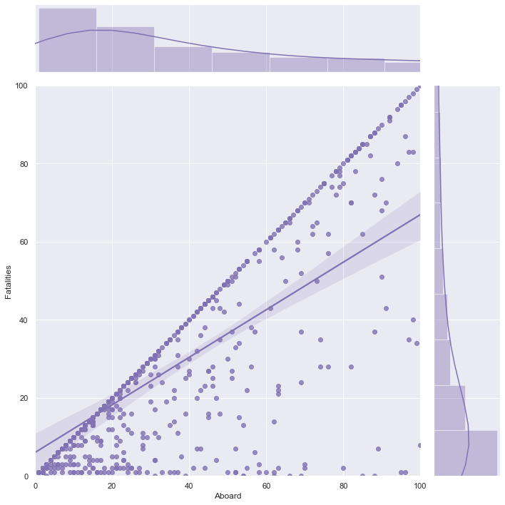

```python
df_plane_clean = df_plane.dropna()
sns.set(style="darkgrid")


g = sns.jointplot("Aboard", "Fatalities", data= df_plane_clean,
                  kind="reg", truncate=False,
                  xlim=(0, 100), ylim=(0, 100),
                  color="m", height=10)
```

The sscatterplot in the jointplot above shows that as the flights aboard the fatalities increase. The datapoints are densely clustered at zero values. The regression line shows that thw two variables "Aboard" and "Fatalities are strongly correlated with some amount of standard deviation represented by the shaded area above and below the regression line. The histogram from the jointplot also shows that as the number of flights that aboard increase the number of fatalities also increase. The normal distribution curve is positively skewed.

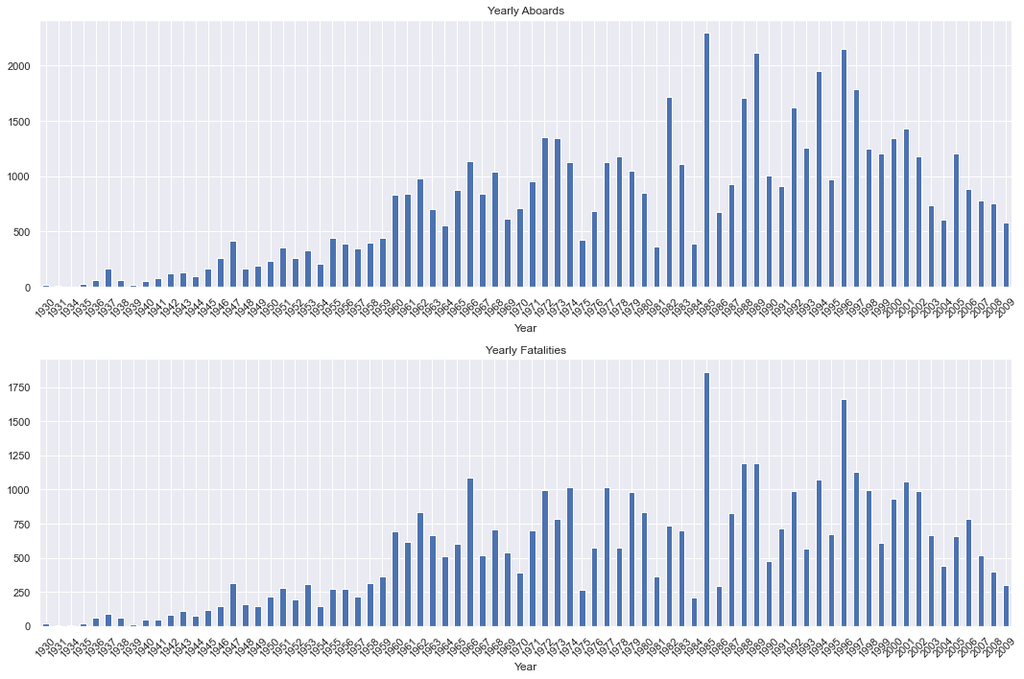

```python
df_graph2 = df_plane_clean[['Date','Aboard','Fatalities']]
df_graph2['Year'] = df_graph2['Date'].apply(lambda x: int(str(x)[-4:]))
yy_dd = df_graph2[['Year','Aboard','Fatalities']].groupby('Year').agg(['count','sum'])
yy_graph,(axy1,axy2)=plt.subplots(2,1,figsize=(15,10))
yy_dd['Aboard','sum'].plot(kind='bar',title='Yearly Aboards',grid=True,ax=axy1,rot=45)
yy_dd['Fatalities','sum'].plot(kind='bar',title='Yearly Fatalities',grid=True,ax=axy2,rot=45)
plt.tight_layout()
```

# Q2 (10 pts): Create a roadmap to process the data

Think of how you will solve the problems in different steps. What kind of data you need to prepare for clustering? How would you run clustering algorithms on the dataset? Please write down your thoughts below and specify your expectations of the clustering results.

Road Map Followed:

-Formulating the Problem: The problem here is that the data on which the cluster analysis is to be performed is of the categorical form and is unclean i.e; requires text processing. The goal is to conduct hierarchial and k means clustering over meaningful words out of all the summaries.

-Selecting a Distance Measure: The data/ meaningful words from each summary are cleaned and seperated as frequency coloumns. This is achieved by text processing, i.e by removing special characters, repetitive/stop words and weird punctuation characters. Categorical data is convertd to numerical data.

-Selection of Clustering Procedure: Either hierarchial or k means clustering. It is important to select the number of clusters which is determined by elbow method, silhoutte method and rule of thumb method.

-Interpreting and profiling the clusters: By rule of thumb obtain the maximum number or range of clusters from the data, which we then apply to the range of clusters obtained by rule of thumb and hence assess the validity of the clustering method by the help of Dendograms and Silhouette method. The value of k is obtained by Elbow method.

My expectations are to understand and analyse the number of clusters in the data, how closely are the clusters related to each other and figure out whether the data points are densely distributed. Primarly, we calculate the differences and similiarity between clusters in the data.

# Q3 (20 pts): Text processing

With each summary, we want to transform the text into a frequency vector. For example, if we have two summaries:

- "The plane was crashed with no alarms. Checking the plane."
- "The plane was crashed on a mountain. "

After some basic text processing such as lowercases and removing stop words, you can create a frequency dataframe like this:

[figure not shown]

Please transpose the dataframe (pandas.DataFrame.transpose) and represent each summary as a frequency vector:

[figure not shown]

We will calculate the similarity between the summaries and run clustering algorithms based on this frequency tables.

```python
df_plane_copy = df_plane_clean.copy()
df_plane_summary = pd.DataFrame(df_plane_copy['Summary'])
df_plane_summary.rename(columns = {'Summary': 'summary'}, inplace = True)
df_plane_summary
```

|  | summary |
| --- | --- |
| 208 | While en route to Los Angeles, the pilot, flyi... |
| 236 | Shortly after taking off from Kansas City, one... |
| 334 | The plane crashed about 11 miles from St. Jose... |
| 354 | The plane crashed while en route from Albuquer... |
| 365 | Crashed 3 miles south of Gilmer. The outboard ... |
| ... | ... |
| 5248 | The commuter plane crashed while attemptiong t... |
| 5251 | The plane was on final approach to Runway 18R ... |
| 5255 | The cargo plane crashed and burst into flame a... |
| 5259 | The passenger plane crashed in poor weather in... |
| 5265 | The Airbus went missing over the AtlantiOcean ... |

944 rows × 1 columns

```python
df_plane_summary['summary'] = df_plane_summary['summary'].str.lower().str.replace("[$&+,:;=?@#|'<>.-^*{}()%!]",'')
```

```python
df_plane_summary['summary'] = df_plane_summary.apply(lambda x: nltk.word_tokenize(x['summary']), axis = 1)
df_plane_summary
```

|  | summary |
| --- | --- |
| 208 | [while, en, route, to, los, angeles, the, pilo... |
| 236 | [shortly, after, taking, off, from, kansas, ci... |
| 334 | [the, plane, crashed, about, miles, from, st, ... |
| 354 | [the, plane, crashed, while, en, route, from, ... |
| 365 | [crashed, miles, south, of, gilmer, the, outbo... |
| ... | ... |
| 5248 | [the, commuter, plane, crashed, while, attempt... |
| 5251 | [the, plane, was, on, final, approach, to, run... |
| 5255 | [the, cargo, plane, crashed, and, burst, into,... |
| 5259 | [the, passenger, plane, crashed, in, poor, wea... |
| 5265 | [the, airbus, went, missing, over, the, atlant... |

944 rows × 1 columns

```python
from nltk.corpus import stopwords
print(stopwords.words('english'))
```

```
['i', 'me', 'my', 'myself', 'we', 'our', 'ours', 'ourselves', 'you', "you're", "you've", "you'll", "you'd", 'your', 'yours', 'yourself', 'yourselves', 'he', 'him', 'his', 'himself', 'she', "she's", 'her', 'hers', 'herself', 'it', "it's", 'its', 'itself', 'they', 'them', 'their', 'theirs', 'themselve…
```

```python
# referred https://pythonhealthcare.org/2018/12/14/101-pre-processing-data-tokenization-stemming-and-removal-of-stop-words/
def no_stop_words(text):
    stop = set(stopwords.words('english'))
    stop_words_removed = []
    for word in text:
        if word not in stop:
            stop_words_removed.append(word)
    return stop_words_removed
```

```python
df_plane_summary['summary'] = df_plane_summary.apply(lambda y: no_stop_words(y['summary']), axis=1)
df_plane_summary['summary']
```

```
208     [en, route, los, angeles, pilot, flying, low, ...
236     [shortly, taking, kansas, city, one, aircrafts...
334     [plane, crashed, miles, st, joseph, heavy, fog...
354     [plane, crashed, en, route, albuquerque, kansa...
365     [crashed, miles, south, gilmer, outboard, engi...
                              ...
5248    [commuter, plane, crashed, attemptiong, land, ...
5251    [plane, final, approach, runway, r, crashed, m...
5255    [cargo, plane, crashed, burst, flame, landed, ...
5259    [passenger, plane, crashed, poor, weather, mou...
5265    [airbus, went, missing, atlantiocean, flight, ...
Name: summary, Length: 944, dtype: object
```

```python
#help taken from Roberto Guzman in this code block
df_plane_new = pd.DataFrame([])

for d in df_plane_summary['summary']:
    content = Counter(d)
    df_plane_new = df_plane_new.append(content, ignore_index = True)

df_plane_new.index = np.arange(1, len(df_plane_new) + 1)
df_plane_new = df_plane_new.rename('summary{}'.format)
```

```python
df_plane_new
```

|  | adverse | altitude | angeles | back | burned | cause | conditions | control | crashed | due | ... | niagara | preliminary | selecting | narita | gergaji | mulia | cindacta | janeiro-galeao | lt | utc |
| --- | --- | --- | --- | --- | --- | --- | --- | --- | --- | --- | --- | --- | --- | --- | --- | --- | --- | --- | --- | --- | --- |
| summary1 | 1.0 | 1.0 | 1.0 | 1.0 | 1.0 | 1.0 | 2.0 | 1.0 | 1.0 | 1.0 | ... | NaN | NaN | NaN | NaN | NaN | NaN | NaN | NaN | NaN | NaN |
| summary2 | NaN | NaN | NaN | NaN | NaN | NaN | NaN | NaN | 1.0 | NaN | ... | NaN | NaN | NaN | NaN | NaN | NaN | NaN | NaN | NaN | NaN |
| summary3 | NaN | NaN | NaN | NaN | NaN | NaN | 2.0 | NaN | 1.0 | NaN | ... | NaN | NaN | NaN | NaN | NaN | NaN | NaN | NaN | NaN | NaN |
| summary4 | NaN | NaN | NaN | NaN | NaN | NaN | NaN | NaN | 2.0 | NaN | ... | NaN | NaN | NaN | NaN | NaN | NaN | NaN | NaN | NaN | NaN |
| summary5 | NaN | NaN | NaN | NaN | NaN | NaN | NaN | 1.0 | 1.0 | NaN | ... | NaN | NaN | NaN | NaN | NaN | NaN | NaN | NaN | NaN | NaN |
| ... | ... | ... | ... | ... | ... | ... | ... | ... | ... | ... | ... | ... | ... | ... | ... | ... | ... | ... | ... | ... | ... |
| summary940 | NaN | NaN | NaN | NaN | NaN | NaN | NaN | NaN | 1.0 | NaN | ... | 1.0 | 1.0 | 1.0 | NaN | NaN | NaN | NaN | NaN | NaN | NaN |
| summary941 | NaN | NaN | NaN | NaN | NaN | NaN | NaN | NaN | 1.0 | NaN | ... | NaN | 1.0 | NaN | NaN | NaN | NaN | NaN | NaN | NaN | NaN |
| summary942 | NaN | NaN | NaN | NaN | NaN | NaN | NaN | NaN | 1.0 | NaN | ... | NaN | NaN | NaN | 1.0 | NaN | NaN | NaN | NaN | NaN | NaN |
| summary943 | NaN | NaN | NaN | NaN | NaN | NaN | NaN | NaN | 1.0 | NaN | ... | NaN | NaN | NaN | NaN | 1.0 | 1.0 | NaN | NaN | NaN | NaN |
| summary944 | NaN | NaN | NaN | NaN | NaN | NaN | NaN | NaN | NaN | NaN | ... | NaN | NaN | NaN | NaN | NaN | NaN | 1.0 | 1.0 | 1.0 | 4.0 |

944 rows × 5770 columns

```python
df_plane_new.fillna(0, inplace = True)
clean_plane_new = df_plane_new.astype(int)
```

```python
clean_plane_new
```

|  | adverse | altitude | angeles | back | burned | cause | conditions | control | crashed | due | ... | niagara | preliminary | selecting | narita | gergaji | mulia | cindacta | janeiro-galeao | lt | utc |
| --- | --- | --- | --- | --- | --- | --- | --- | --- | --- | --- | --- | --- | --- | --- | --- | --- | --- | --- | --- | --- | --- |
| summary1 | 1 | 1 | 1 | 1 | 1 | 1 | 2 | 1 | 1 | 1 | ... | 0 | 0 | 0 | 0 | 0 | 0 | 0 | 0 | 0 | 0 |
| summary2 | 0 | 0 | 0 | 0 | 0 | 0 | 0 | 0 | 1 | 0 | ... | 0 | 0 | 0 | 0 | 0 | 0 | 0 | 0 | 0 | 0 |
| summary3 | 0 | 0 | 0 | 0 | 0 | 0 | 2 | 0 | 1 | 0 | ... | 0 | 0 | 0 | 0 | 0 | 0 | 0 | 0 | 0 | 0 |
| summary4 | 0 | 0 | 0 | 0 | 0 | 0 | 0 | 0 | 2 | 0 | ... | 0 | 0 | 0 | 0 | 0 | 0 | 0 | 0 | 0 | 0 |
| summary5 | 0 | 0 | 0 | 0 | 0 | 0 | 0 | 1 | 1 | 0 | ... | 0 | 0 | 0 | 0 | 0 | 0 | 0 | 0 | 0 | 0 |
| ... | ... | ... | ... | ... | ... | ... | ... | ... | ... | ... | ... | ... | ... | ... | ... | ... | ... | ... | ... | ... | ... |
| summary940 | 0 | 0 | 0 | 0 | 0 | 0 | 0 | 0 | 1 | 0 | ... | 1 | 1 | 1 | 0 | 0 | 0 | 0 | 0 | 0 | 0 |
| summary941 | 0 | 0 | 0 | 0 | 0 | 0 | 0 | 0 | 1 | 0 | ... | 0 | 1 | 0 | 0 | 0 | 0 | 0 | 0 | 0 | 0 |
| summary942 | 0 | 0 | 0 | 0 | 0 | 0 | 0 | 0 | 1 | 0 | ... | 0 | 0 | 0 | 1 | 0 | 0 | 0 | 0 | 0 | 0 |
| summary943 | 0 | 0 | 0 | 0 | 0 | 0 | 0 | 0 | 1 | 0 | ... | 0 | 0 | 0 | 0 | 1 | 1 | 0 | 0 | 0 | 0 |
| summary944 | 0 | 0 | 0 | 0 | 0 | 0 | 0 | 0 | 0 | 0 | ... | 0 | 0 | 0 | 0 | 0 | 0 | 1 | 1 | 1 | 4 |

944 rows × 5770 columns

Clustering is performed on numerical data and hence we generate a frequency dataframe of all the meaningful words from the texts in the summary column of the original dataframe. The dataframe shows how many times each word (represented as column name) is found in each summary text.

# Q4 (20 pts): Clustering

- Please run both the hierarchical clustering and k-means algorithms on the created dataframe.
- What do the results look like? Drawing the hierarachical clustering dendrogram may be helpful (or it might not -- how would you simplify an overly dense dendrogram?).
- How did you choose the number of clusters? For k-means clustering, please use the four methods mentioned in our lecture to choose an appropriate number of clusters.

```python
def plot_dendrogram(model, **kwargs):

    # Children of hierarchical clustering
    children = model.children_

    # Distances between each pair of children
    # Since we don't have this information, we can use a uniform one for plotting
    distance = np.arange(children.shape[0])

    # The number of observations contained in each cluster level
    no_of_observations = np.arange(2, children.shape[0]+2)

    # Create linkage matrix and then plot the dendrogram
    linkage_matrix = np.column_stack([children, distance, no_of_observations]).astype(float)

    # Plot the corresponding dendrogram
    dendrogram(linkage_matrix, **kwargs)
```

```python
model = AgglomerativeClustering(n_clusters=21) # we can make up the value for clusters
model.fit_predict(clean_plane_new)
clean_plane_new['cluster'] = model.labels_
```

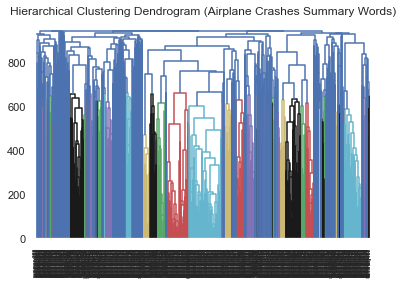

```python
plt.title('Hierarchical Clustering Dendrogram (Airplane Crashes Summary Words)')
plot_dendrogram(model,labels=clean_plane_new.index.values)
plt.xticks(rotation=90)
plt.savefig('airplanewords.pdf',format='pdf')
plt.figure(figsize=(20, 20))
plt.show()
```

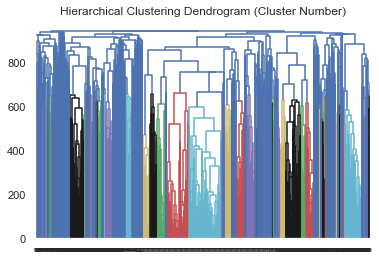

```python
plt.title('Hierarchical Clustering Dendrogram (Cluster Number)')
plot_dendrogram(model,labels=model.labels_)
plt.xticks(rotation=0)
plt.figure(figsize=(20, 20))
plt.show()
```

From the hierarchical clustering performed above, it is very difficult to interpret the results as the dendograms obtained are highly crowded and dense. I believe this is mostly because the data is very large and hence a lot of crowding is seen on the x-axis.

```python
kmeans = KMeans(n_clusters=3) # start with 3 clusters
kmeans.fit(clean_plane_new)
print("Labels:")
print(kmeans.labels_)
```

```
Labels:
[0 0 0 0 0 0 0 0 0 0 0 2 0 0 0 0 0 0 2 0 0 0 0 0 0 0 0 2 0 2 0 0 0 0 0 2 0
 2 0 0 0 0 0 0 0 0 0 0 0 0 0 0 0 2 0 0 1 2 1 0 0 0 0 2 2 0 2 0 0 0 1 0 0 2
 0 0 0 2 0 0 0 2 1 0 0 1 0 0 1 0 2 2 0 0 2 1 0 0 0 0 1 1 2 0 0 0 2 0 0 0 1
 2 0 0 0 0 1 0 0 0 2 0 0 0 0 0 0 0 0 2 0 1 0 2 0 0 0 1 1 0 0 0 2 2 0 1 0 0
 0 0 1 0 0 0 2 0 1 0 0 1 0 2 0 0 0 0 0 1 0 1 0 0 2 0 2 2 0 0 0 0 0 0 2 0 2
 0 0 1 1 0 0 0 1 0 0 0 1 0 0 1 0 2 1 0 0 0 0 0 0 0 0 0 0 0 2 0 2 2 0 0 0 0
 0 0 0 0 0 2 2 0 2 0 0 0 0 0 2 0 0 0 0 1 2 0 1 0 2 0 0 0 0 0 0 0 0 0 1 2 0
 1 0 0 0 0 0 2 0 0 2 1 1 0 0 0 0 1 0 0 0 0 0 0 0 2 0 0 1 0 0 0 1 1 0 2 0 2
 1 0 1 0 1 0 0 0 0 0 0 0 0 0 0 0 2 0 1 0 2 0 0 0 0 0 2 0 0 2 2 1 0 0 2 0 0
 0 0 2 0 1 0 1 2 2 0 0 2 1 0 0 2 1 1 1 0 0 2 0 0 2 0 0 0 0 0 0 2 1 0 2 2 0
 2 1 2 2 0 2 0 0 2 2 0 2 2 0 0 2 1 0 1 0 2 0 0 2 0 0 0 0 0 0 2 2 2 0 0 0 0
 0 0 1 0 2 0 0 0 0 0 0 1 0 2 2 0 0 1 1 0 0 1 2 1 2 1 2 0 2 2 0 0 0 2 0 1 0
 2 1 0 0 2 0 0 0 0 2 2 2 2 0 2 0 0 0 0 0 0 0 1 1 0 0 0 2 0 0 0 1 0 0 0 0 0
 1 2 0 0 0 1 0 2 0 0 0 0 0 0 0 0 2 0 0 0 0 0 0 0 0 0 0 2 2 2 2 0 2 0 2 0 1
 0 0 0 0 0 2 0 0 1 0 0 0 0 1 2 1 0 2 0 2 0 0 2 0 0 0 0 0 0 0 0 2 2 2 0 2 1
 0 0 0 0 0 0 2 0 2 2 2 0 2 0 0 0 0 2 0 0 2 0 0 0 2 0 0 0 0 2 2 1 0 0 0 0 0
 0 0 2 2 0 0 2 0 2 0 0 0 0 2 0 0 0 0 0 0 0 0 1 0 0 0 1 1 0 0 0 0 2 0 2 2 0
 0 0 0 2 0 2 0 0 0 0 2 0 1 2 2 2 0 2 0 1 0 2 2 2 0 2 0 0 0 0 0 0 2 1 0 0 0
 0 0 0 0 0 2 0 0 0 0 0 2 0 0 2 2 0 0 2 0 2 0 2 0 0 2 2 0 0 0 0 2 2 0 0 0 0
 0 2 2 0 0 0 0 0 2 0 0 2 0 0 0 0 2 2 0 1 0 0 2 0 0 0 2 2 0 0 2 2 0 0 0 0 2
 0 2 1 0 2 2 0 0 2 2 0 0 2 0 0 0 1 0 0 2 0 0 0 0 0 0 0 2 0 2 0 0 0 2 0 0 0
 0 0 2 0 0 2 0 1 0 2 0 0 0 0 0 1 0 0 2 0 0 0 2 0 0 2 0 0 0 1 2 0 0 0 2 2 0
 2 0 0 0 0 0 0 0 0 2 0 0 2 0 2 0 0 0 0 0 0 0 0 0 0 0 2 0 0 0 0 0 0 0 0 0 2
 2 0 0 0 0 2 0 2 0 0 0 0 0 2 2 0 0 0 0 0 0 0 0 0 0 0 2 0 2 0 0 0 0 0 0 0 0
 0 0 0 2 0 2 0 0 0 2 2 2 0 0 0 0 0 2 0 0 0 0 0 0 1 0 2 1 0 2 0 0 2 2 2 0 2
 0 2 2 0 0 0 2 0 0 2 2 0 2 0 0 2 2 0 0]
```

```python
kmeans = KMeans(n_clusters=5) # move to 5 clusters
kmeans.fit(clean_plane_new)
print("Labels:")
print(kmeans.labels_)
```

```
Labels:
[1 1 1 1 3 3 1 1 1 1 1 2 3 1 1 1 1 3 4 1 1 1 1 3 3 3 1 2 1 2 3 1 1 1 1 2 3
 2 3 1 1 3 1 3 3 1 3 3 1 3 1 1 1 2 1 3 0 2 0 3 1 1 3 2 2 1 2 1 1 1 0 1 1 2
 1 1 3 4 1 3 3 2 0 3 1 0 3 3 0 1 2 2 1 3 2 0 1 3 3 3 0 0 2 3 1 1 2 3 1 1 0
 2 1 1 3 1 0 3 1 3 4 1 1 3 3 3 3 3 1 2 1 0 3 2 3 3 3 0 0 1 3 1 4 2 3 0 1 1
 1 1 0 3 1 1 2 3 0 1 3 0 3 2 1 1 1 1 1 0 1 0 3 3 2 1 2 2 1 1 1 3 1 1 4 3 2
 1 1 0 0 3 3 1 0 1 1 3 0 1 3 0 3 2 0 3 3 1 3 3 1 1 3 1 1 1 4 1 2 2 1 1 3 3
 1 3 3 1 3 4 4 3 2 1 1 3 1 1 2 3 3 3 1 0 4 1 0 1 2 3 3 1 1 1 1 1 1 3 0 2 1
 0 1 1 3 1 1 2 1 1 2 0 0 1 1 3 1 0 1 3 1 3 1 1 3 2 1 1 3 1 1 3 3 3 1 4 1 4
 0 3 0 3 0 1 1 1 3 1 1 1 1 1 1 1 2 3 0 3 2 1 1 1 1 1 2 1 1 2 2 0 3 1 2 1 1
 3 3 2 3 0 1 0 4 2 1 1 2 0 3 1 2 0 0 3 1 3 2 3 1 2 1 1 1 1 1 1 4 0 3 2 2 3
 4 0 2 4 1 2 3 3 2 2 1 2 2 1 1 4 0 1 0 1 2 1 3 2 1 1 1 1 1 1 4 2 4 3 1 1 1
 3 3 0 1 2 3 1 1 3 1 1 0 3 4 2 3 1 0 0 1 3 0 2 0 2 0 2 1 2 2 1 3 1 2 1 0 1
 2 0 3 1 2 1 3 3 3 4 2 4 2 3 4 1 1 1 3 1 3 3 0 0 3 1 1 2 1 1 3 0 1 3 3 1 1
 0 2 3 1 1 0 3 2 3 3 3 1 1 1 1 1 2 3 1 1 1 3 1 1 3 1 1 4 2 2 2 3 2 3 4 3 0
 1 3 1 1 1 2 3 3 0 3 1 1 3 0 2 0 1 2 1 4 1 3 2 3 1 1 3 3 3 3 1 2 2 4 1 2 0
 1 1 1 1 1 3 4 3 2 2 2 3 2 1 3 3 1 4 3 3 4 1 1 3 2 1 1 1 1 2 2 0 1 1 1 3 1
 1 1 4 4 1 3 2 1 2 1 1 3 3 2 3 3 1 3 3 1 3 1 0 3 3 1 0 0 3 3 1 1 2 3 4 2 1
 3 1 3 2 1 2 1 1 3 3 4 1 0 2 2 2 1 2 1 0 3 4 4 2 1 4 3 1 1 1 3 1 2 3 1 1 1
 3 1 1 1 1 4 3 3 3 3 3 2 1 3 2 4 1 1 2 1 4 1 4 3 1 4 4 3 3 1 1 2 4 3 1 3 1
 3 4 2 3 1 3 1 1 2 3 1 4 3 1 1 1 2 4 1 0 1 1 4 3 1 3 4 4 1 1 2 2 1 1 3 1 2
 3 4 0 1 2 2 3 1 2 4 1 1 4 1 1 3 0 3 3 4 1 1 1 1 3 3 1 2 1 2 3 1 1 4 1 1 3
 1 1 2 3 1 4 1 0 3 2 1 3 1 3 1 0 1 1 4 3 3 1 4 1 1 2 3 1 1 0 2 1 1 1 2 4 4
 2 1 1 1 1 1 1 1 1 4 3 1 4 1 4 1 1 3 1 3 1 1 1 1 1 1 2 1 1 1 1 1 3 1 1 3 4
 2 3 1 1 1 2 1 4 1 1 1 3 1 2 2 1 1 1 1 1 1 1 1 1 1 1 2 1 2 1 1 1 1 1 1 1 1
 1 3 1 2 3 2 1 3 1 2 4 4 1 1 1 1 1 2 3 1 1 1 1 1 0 1 4 0 1 2 1 1 2 2 2 1 2
 1 2 2 1 1 3 2 1 1 2 2 1 2 1 1 2 2 1 1]
```

```python
clean_plane_newc = clean_plane_new.copy()
```

```python
np.sqrt(len(clean_plane_newc)/2) #rule of thumb
```

```
21.72556098240043
```

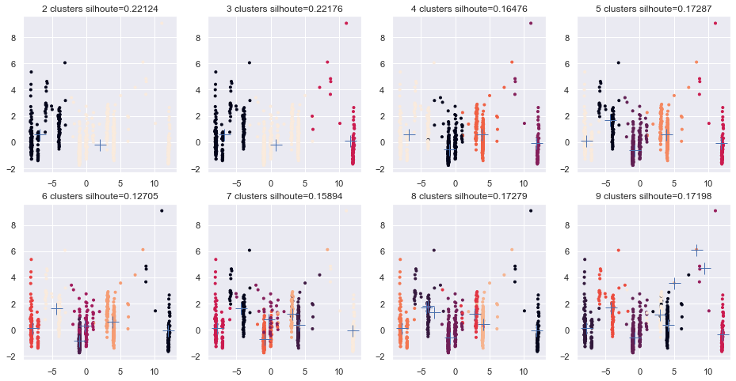

```python
pca = PCA(n_components=2).fit(clean_plane_newc)
airplane_df = pca.transform(clean_plane_newc)

plt.figure(figsize=(16, 8))
scores, n_clusters, preds = [], [], []
for i in range(2, 10):
    kmean = KMeans(n_clusters = i).fit(clean_plane_newc)
    scores.append(kmean.score(clean_plane_newc))
    n_clusters.append(i)
    pred = kmean.predict(clean_plane_newc)
    preds.append(pred)
    plt.subplot(2, 4, i - 1)
    plt.title(f"{i} clusters silhoute={np.round(silhouette_score(clean_plane_newc, pred), decimals=5)}")
    plt.scatter(airplane_df[:, 0], airplane_df[:, 1], c=pred, marker = '.')

    airplane_centroids = kmean.cluster_centers_
    airplane_centroids2d = pca.transform(airplane_centroids)
    plt.plot(airplane_centroids2d[:, 0], airplane_centroids2d[:, 1], 'b+', markersize=15)
```

[output not shown]

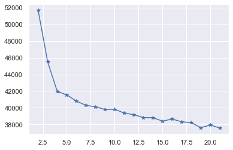

```python
#elbow method
text = []
for k in range(2,22):
    k_means = KMeans(init='k-means++', n_clusters=k, n_init=10)
    k_means.fit(clean_plane_newc)
    text.append(k_means.inertia_)

fig, ax = plt.subplots()
plt.plot(range(2,22), text, 'b*-')
plt.xlim(1, plt.xlim()[1])
```

```
(1.0, 21.95)
```

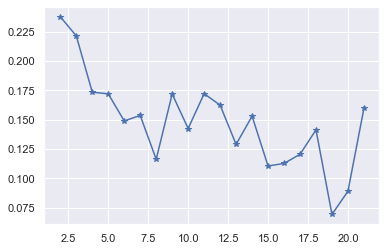

```python
#silhouette method
text = []
for k in range(2,22):
    k_means = KMeans(init='k-means++', n_clusters=k, n_init=10)
    k_means.fit(clean_plane_newc)
    text.append(metrics.silhouette_score(clean_plane_newc, k_means.labels_))

# kIdx = np.argmax(cost)
fig, ax = plt.subplots()
plt.plot(range(2,22), text, 'b*-')
plt.xlim(1, plt.xlim()[1])
```

```python
plane_sample = clean_plane_new.iloc[100:115]
plane_sample
```

|  | adverse | altitude | angeles | back | burned | cause | conditions | control | crashed | due | ... | preliminary | selecting | narita | gergaji | mulia | cindacta | janeiro-galeao | lt | utc | cluster |
| --- | --- | --- | --- | --- | --- | --- | --- | --- | --- | --- | --- | --- | --- | --- | --- | --- | --- | --- | --- | --- | --- |
| summary101 | 0 | 0 | 0 | 0 | 0 | 0 | 0 | 0 | 1 | 0 | ... | 0 | 0 | 0 | 0 | 0 | 0 | 0 | 0 | 0 | 20 |
| summary102 | 0 | 1 | 0 | 0 | 0 | 0 | 0 | 0 | 0 | 0 | ... | 0 | 0 | 0 | 0 | 0 | 0 | 0 | 0 | 0 | 20 |
| summary103 | 0 | 0 | 0 | 0 | 0 | 0 | 0 | 0 | 0 | 0 | ... | 0 | 0 | 0 | 0 | 0 | 0 | 0 | 0 | 0 | 0 |
| summary104 | 0 | 0 | 0 | 0 | 0 | 1 | 0 | 1 | 0 | 0 | ... | 0 | 0 | 0 | 0 | 0 | 0 | 0 | 0 | 0 | 12 |
| summary105 | 0 | 0 | 0 | 0 | 0 | 0 | 1 | 0 | 1 | 0 | ... | 0 | 0 | 0 | 0 | 0 | 0 | 0 | 0 | 0 | 8 |
| summary106 | 0 | 1 | 0 | 0 | 0 | 0 | 0 | 0 | 1 | 0 | ... | 0 | 0 | 0 | 0 | 0 | 0 | 0 | 0 | 0 | 7 |
| summary107 | 0 | 0 | 0 | 0 | 0 | 0 | 1 | 0 | 0 | 0 | ... | 0 | 0 | 0 | 0 | 0 | 0 | 0 | 0 | 0 | 1 |
| summary108 | 0 | 0 | 0 | 0 | 0 | 0 | 0 | 0 | 1 | 0 | ... | 0 | 0 | 0 | 0 | 0 | 0 | 0 | 0 | 0 | 12 |
| summary109 | 0 | 1 | 0 | 0 | 0 | 0 | 0 | 0 | 1 | 0 | ... | 0 | 0 | 0 | 0 | 0 | 0 | 0 | 0 | 0 | 7 |
| summary110 | 0 | 0 | 0 | 0 | 0 | 0 | 0 | 1 | 0 | 0 | ... | 0 | 0 | 0 | 0 | 0 | 0 | 0 | 0 | 0 | 7 |
| summary111 | 0 | 1 | 0 | 0 | 0 | 0 | 0 | 0 | 1 | 0 | ... | 0 | 0 | 0 | 0 | 0 | 0 | 0 | 0 | 0 | 20 |
| summary112 | 0 | 0 | 0 | 0 | 0 | 0 | 1 | 0 | 1 | 0 | ... | 0 | 0 | 0 | 0 | 0 | 0 | 0 | 0 | 0 | 0 |
| summary113 | 0 | 1 | 0 | 0 | 0 | 0 | 1 | 0 | 1 | 0 | ... | 0 | 0 | 0 | 0 | 0 | 0 | 0 | 0 | 0 | 7 |
| summary114 | 0 | 0 | 0 | 0 | 0 | 0 | 0 | 0 | 0 | 0 | ... | 0 | 0 | 0 | 0 | 0 | 0 | 0 | 0 | 0 | 7 |
| summary115 | 0 | 0 | 0 | 0 | 0 | 0 | 0 | 0 | 1 | 0 | ... | 0 | 0 | 0 | 0 | 0 | 0 | 0 | 0 | 0 | 12 |

15 rows × 5771 columns

```python
model_new = AgglomerativeClustering(n_clusters=5) # we can make up the value for clusters
model_new.fit_predict(plane_sample)
plane_sample['cluster'] = model_new.labels_
```

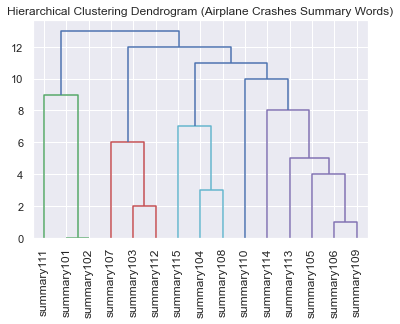

```python
plt.title('Hierarchical Clustering Dendrogram (Airplane Crashes Summary Words)')
plot_dendrogram(model_new,labels=plane_sample.index.values)
plt.xticks(rotation=90)
plt.savefig('airplanewords.pdf',format='pdf')
plt.figure(figsize=(20, 15))
plt.show()
```

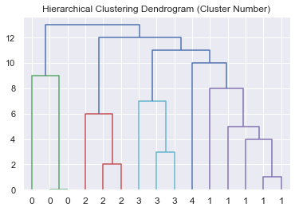

```python
plt.title('Hierarchical Clustering Dendrogram (Cluster Number)')
plot_dendrogram(model_new,labels=model_new.labels_)
plt.xticks(rotation=0)
plt.figure(figsize=(20, 15))
plt.show()
```